# **CIFAR-10 Image Classification using Convolutional Neural Networks**

The model used in this code is a sequential CNN that consists of three convolutional layers followed by two dense layers. The first convolutional layer has 32 filters with a kernel size of 3x3 and uses the ReLU activation function. The second convolutional layer has 64 filters with a kernel size of 3x3 and also uses the ReLU activation function. The third convolutional layer has 64 filters with a kernel size of 3x3 and again uses the ReLU activation function.

After the final convolutional layer, the output is flattened and passed through two dense layers. The first dense layer has 64 units and uses the ReLU activation function. The final dense layer has 10 units (equal to the number of categories in the dataset) and does not have an activation function, as it is followed by the softmax activation function during training.

The model is compiled with the Adam optimizer, which is an adaptive learning rate optimization algorithm, and the sparse categorical cross-entropy loss function, which is used for multiclass classification problems. The model is trained for 10 epochs and evaluated on the test data using accuracy as the evaluation metric.

```python
import tensorflow as tf
from tensorflow.keras import layers, models
from tensorflow.keras.datasets import cifar10

# Load the CIFAR-10 dataset
(x_train, y_train), (x_test, y_test) = cifar10.load_data()

# Normalize pixel values to be between 0 and 1
x_train, x_test = x_train / 255.0, x_test / 255.0


# Define the model architecture
model = models.Sequential([
    layers.Conv2D(32, (3, 3), activation='relu', input_shape=(32, 32, 3)),
    layers.MaxPooling2D((2, 2)),
    layers.Conv2D(64, (3, 3), activation='relu'),
    layers.MaxPooling2D((2, 2)),
    layers.Conv2D(64, (3, 3), activation='relu'),
    layers.Flatten(),
    layers.Dense(64, activation='relu'),
    layers.Dense(10)
])

# Compile the model
model.compile(optimizer='adam',
              loss=tf.keras.losses.SparseCategoricalCrossentropy(from_logits=True),
              metrics=['accuracy'])

# Train the model
history = model.fit(x_train, y_train, epochs=10,
                    validation_data=(x_test, y_test))

# Evaluate the model on the test data
test_loss, test_acc = model.evaluate(x_test, y_test, verbose=2)
print("Test Accuracy:", test_acc)
```

```
313/313 - 1s - loss: 0.8868 - accuracy: 0.6992 - 947ms/epoch - 3ms/step
Test Accuracy: 0.6991999745368958
```

```python
import numpy as np

# Select an image from the test set
image = x_test[0]

# Make a prediction on the image
prediction = model.predict(np.array([image]))

# Print the predicted class
print("Predicted Class:", np.argmax(prediction))
```

[output not shown]

```python
from tensorflow.keras.utils import plot_model

# Plot the model architecture
plot_model(model, to_file='model.png', show_shapes=True)
```

```
You must install pydot (`pip install pydot`) and install graphviz (see instructions at https://graphviz.gitlab.io/download/) for plot_model to work.
```

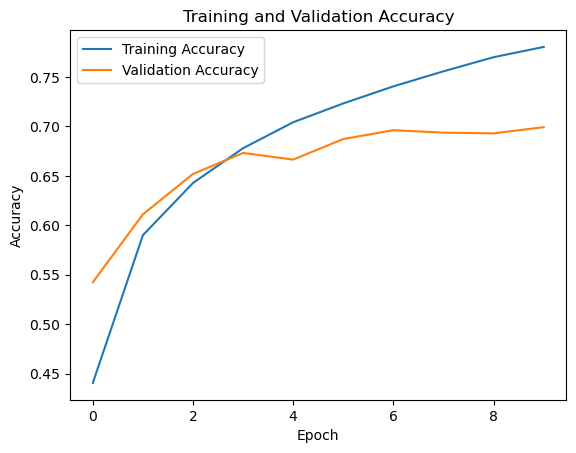

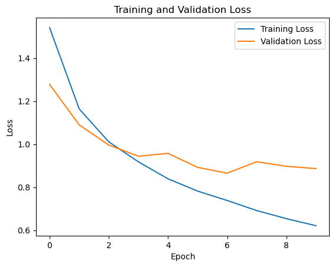

```python
import matplotlib.pyplot as plt

# Plot the training and validation accuracy over epochs
plt.plot(history.history['accuracy'], label='Training Accuracy')
plt.plot(history.history['val_accuracy'], label='Validation Accuracy')
plt.title('Training and Validation Accuracy')
plt.xlabel('Epoch')
plt.ylabel('Accuracy')
plt.legend()
plt.show()

# Plot the training and validation loss over epochs
plt.plot(history.history['loss'], label='Training Loss')
plt.plot(history.history['val_loss'], label='Validation Loss')
plt.title('Training and Validation Loss')
plt.xlabel('Epoch')
plt.ylabel('Loss')
plt.legend()
plt.show()
```

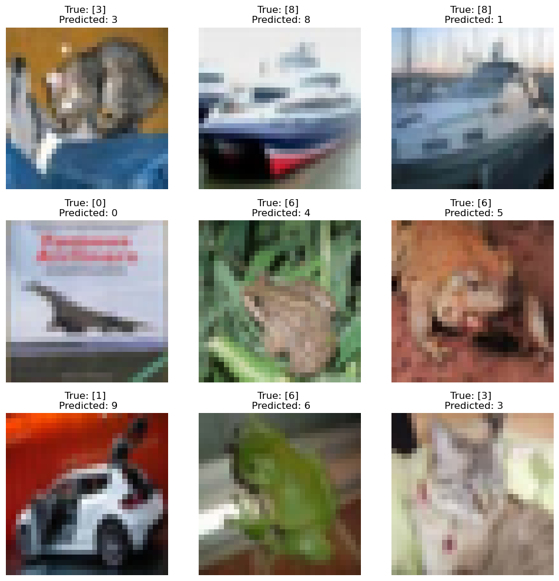

```python
import seaborn as sns

# Get the predicted classes for the test set
y_pred = np.argmax(model.predict(x_test), axis=1)

# Plot some example predictions
fig, axes = plt.subplots(nrows=3, ncols=3, figsize=(10, 10))
for i, ax in enumerate(axes.flat):
    ax.imshow(x_test[i])
    ax.set_title("True: {} \n Predicted: {}".format(y_test[i], y_pred[i]))
    ax.axis('off')
plt.tight_layout()
plt.show()
```

```python
class_labels = ['airplane', 'automobile', 'bird', 'cat', 'deer', 'dog', 'frog', 'horse', 'ship', 'truck']
```

```python
label_dict = {i:class_labels[i] for i in range(10)}
y_train = np.array([label_dict[y] for y in y_train.flatten()])
y_test = np.array([label_dict[y] for y in y_test.flatten()])
y_pred = np.array([label_dict[y] for y in y_pred])
```

#### Result

The model achieved a test accuracy of 69.92% on the CIFAR-10 dataset using a Convolutional Neural Network architecture with 3 convolutional layers and 2 fully connected layers. The model was trained for 10 epochs using the Adam optimizer and the Sparse Categorical Crossentropy loss function. we can see that there is a slight overfitting in the model when ecoch or data is increaseing and that will be common in machine learning algorithms.

# **CIFAR-10 Image Classification using Convolutional Neural Networks advanced version**

The second one i have used is the Convolutional Neural Network (CNN) model that is used for image classification on the CIFAR-10 dataset is same as the last model but i have added more layers and Dropout layers to the dataset. This model consists of multiple layers of Conv2D, MaxPooling2D, and Dropout layers followed by Dense layers with ReLU and Softmax activation functions. The first layer takes the input image of shape (32, 32, 3) and applies a 3x3 filter with 32 output filters followed by MaxPooling2D to reduce the dimensions of the feature map. This is repeated with 64 and 128 output filters in the subsequent layers. Dropout layers are used to prevent overfitting of the model. Finally, the output is flattened and fed into two Dense layers with 128 and 10 output neurons respectively, for classification.

The model is compiled using the categorical_crossentropy loss function and Adam optimizer with a learning rate of 0.001, and accuracy metric is used for evaluation. The model is trained for 50 epochs with a batch size of 128 and 10% of the training data used for validation.

The main difference between the two models is the architecture and the number of layers used. The first model is a simple sequential CNN consisting of three convolutional layers and two dense layers. The second model is a more complex CNN with multiple layers of Conv2D, MaxPooling2D, and Dropout layers followed by two Dense layers. Additionally, the second model has more filters in the convolutional layers and is trained for 50 epochs compared to the 10 epochs of the first model. This results in the second model having a higher capacity and potentially better accuracy.

```
Test loss: 0.5880512595176697
Test accuracy: 0.8026999831199646
```

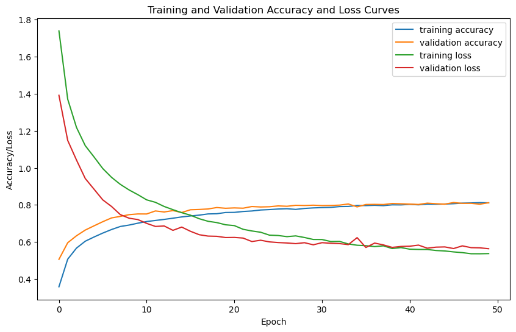

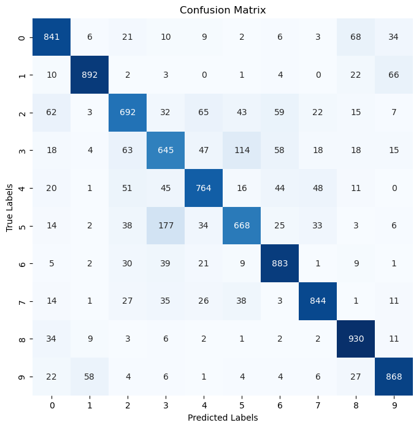

```python
import numpy as np
import matplotlib.pyplot as plt
import seaborn as sns
from sklearn.metrics import confusion_matrix
from tensorflow.keras.datasets import cifar10
from tensorflow.keras.layers import Conv2D, MaxPooling2D, Dropout, Flatten, Dense
from tensorflow.keras.models import Sequential
from tensorflow.keras.optimizers import Adam

# Load the CIFAR-10 dataset
(x_train, y_train), (x_test, y_test) = cifar10.load_data()

# Preprocess the dataset
x_train = x_train.astype('float32') / 255
x_test = x_test.astype('float32') / 255
mean_pixel = x_train.mean(axis=0)
x_train -= mean_pixel
x_test -= mean_pixel

# Define the CNN architecture
model = Sequential([
    Conv2D(32, (3, 3), activation='relu', padding='same', input_shape=(32, 32, 3)),
    MaxPooling2D((2, 2)),
    Dropout(0.25),
    Conv2D(64, (3, 3), activation='relu', padding='same'),
    MaxPooling2D((2, 2)),
    Dropout(0.25),
    Conv2D(128, (3, 3), activation='relu', padding='same'),
    MaxPooling2D((2, 2)),
    Dropout(0.25),
    Flatten(),
    Dense(128, activation='relu'),
    Dropout(0.5),
    Dense(10, activation='softmax')
])

# Compile the model
model.compile(loss='categorical_crossentropy', optimizer=Adam(lr=0.001), metrics=['accuracy'])

# Train the model
history = model.fit(x_train, tf.keras.utils.to_categorical(y_train), epochs=50, batch_size=128, validation_split=0.1)

# Evaluate the model
loss, accuracy = model.evaluate(x_test, tf.keras.utils.to_categorical(y_test))
print("Test loss:", loss)
print("Test accuracy:", accuracy)

# Plot the training and validation accuracy and loss curves
plt.figure(figsize=(10, 6))
plt.plot(history.history['accuracy'], label='training accuracy')
plt.plot(history.history['val_accuracy'], label='validation accuracy')
plt.plot(history.history['loss'], label='training loss')
plt.plot(history.history['val_loss'], label='validation loss')
plt.title('Training and Validation Accuracy and Loss Curves')
plt.xlabel('Epoch')
plt.ylabel('Accuracy/Loss')
plt.legend()
plt.show()

# Create a confusion matrix
y_pred = model.predict(x_test)
y_pred_classes = np.argmax(y_pred, axis=1)
y_test_classes = np.argmax(tf.keras.utils.to_categorical(y_test), axis=1)
cm = confusion_matrix(y_test_classes, y_pred_classes)

# Plot the confusion matrix
plt.figure(figsize=(8, 8))
sns.heatmap(cm, annot=True, cmap='Blues', fmt='d', cbar=False)
plt.title('Confusion Matrix')
plt.xlabel('Predicted Labels')
plt.ylabel('True Labels')
plt.show()
```

#### Result:

The confusion matrix shows that the model performed well in correctly classifying most of the images, with higher numbers on the diagonal indicating correct predictions. However, there were some misclassifications as well, as indicated by the non-zero numbers off the diagonal.

## **CIFAR 10 using Deep Neural Networks**

The DNN architecture used in this task consists of three dense (fully connected) layers. The input to the model is a 32x32x3 image, which is flattened to a 1D array of length 32x32x3=3072. This flattened input is then passed through two hidden layers with 256 neurons each and ReLU activation functions. Finally, the output layer has 10 neurons with softmax activation functions, which gives the probability distribution over the 10 classes.

The model is compiled with stochastic gradient descent (SGD) optimizer with a learning rate of 0.01 and categorical cross-entropy loss function, which is commonly used for multi-class classification tasks. The accuracy metric is also calculated during training and evaluation.

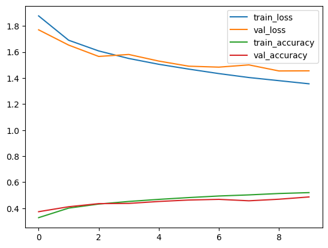

```
              precision    recall  f1-score   support

           0       0.43      0.65      0.52      1000
           1       0.59      0.64      0.61      1000
           2       0.41      0.34      0.37      1000
           3       0.42      0.17      0.24      1000
           4       0.49      0.37      0.42      1000
           5       0.38      0.44      0.41      1000
           6       0.64      0.42      0.51      1000
           7       0.50      0.62      0.56      1000
           8       0.48      0.75      0.58      1000
           9       0.60      0.47      0.53      1000

    accuracy                           0.49     10000
   macro avg       0.49      0.49      0.47     10000
weighted avg       0.49      0.49      0.47     10000

[[651  26  25   4  17  21   8  28 197  23]
 [ 68 637   5   4   5  22   8  21 127 103]
 [175  24 337  37  92 118  46  98  58  15]
 [112  36  69 172  45 279  52 100  84  51]
 [114  25 147  28 369  59  63 127  63   5]
 [ 73  20  80  79  46 442  32 126  77  25]
 [ 55  25  98  51 128 113 419  49  43  19]
 [ 96  24  43  21  43  67  11 624  38  33]
 [103  54   6   9   6  19   1  14 752  36]
 [ 75 208   8   8   3  25  14  56 135 468]]
```

```python
import numpy as np
from keras.datasets import cifar10
from keras.models import Sequential
from keras.layers import Dense, Flatten
from keras.optimizers import SGD
from keras.utils import to_categorical
from sklearn.metrics import classification_report, confusion_matrix
import matplotlib.pyplot as plt

# load the CIFAR-10 dataset
(X_train, y_train), (X_test, y_test) = cifar10.load_data()

# normalize the images to the range [0, 1]
X_train = X_train.astype('float32') / 255.0
X_test = X_test.astype('float32') / 255.0

# one-hot encode the class labels
y_train = to_categorical(y_train)
y_test = to_categorical(y_test)

# define the model
model = Sequential()
model.add(Flatten(input_shape=(32, 32, 3)))
model.add(Dense(256, activation='relu'))
model.add(Dense(256, activation='relu'))
model.add(Dense(10, activation='softmax'))

# compile the model
sgd = SGD(learning_rate=0.01)
model.compile(loss='categorical_crossentropy', optimizer=sgd, metrics=['accuracy'])

# train the model
history = model.fit(X_train, y_train, batch_size=32, epochs=10, validation_data=(X_test, y_test))

# plot the training loss and accuracy
plt.plot(history.history['loss'], label='train_loss')
plt.plot(history.history['val_loss'], label='val_loss')
plt.plot(history.history['accuracy'], label='train_accuracy')
plt.plot(history.history['val_accuracy'], label='val_accuracy')
plt.legend()
plt.show()

# generate predictions on the test set
y_pred = model.predict(X_test)
y_pred_classes = np.argmax(y_pred, axis=1)
y_true_classes = np.argmax(y_test, axis=1)

# generate and print the classification report and confusion matrix
print(classification_report(y_true_classes, y_pred_classes))
print(confusion_matrix(y_true_classes, y_pred_classes))
```